# 2) Example of GMA-SMA models for varietal mixtures in microplots

## 3.2 Simulate the phenotypes

```r
nbMixes <- 1000
design <- getDesignBinaryVarMix(levGenos, nbMixes = nbMixes)
tmp <- getMixturesPerGeno(getMixtureList(design$combs))
table(sapply(tmp, length)) # each genotype is in the same nb of mixtures -> balanced design
```

```
##
##  9 10 11
## 54 92 54
```

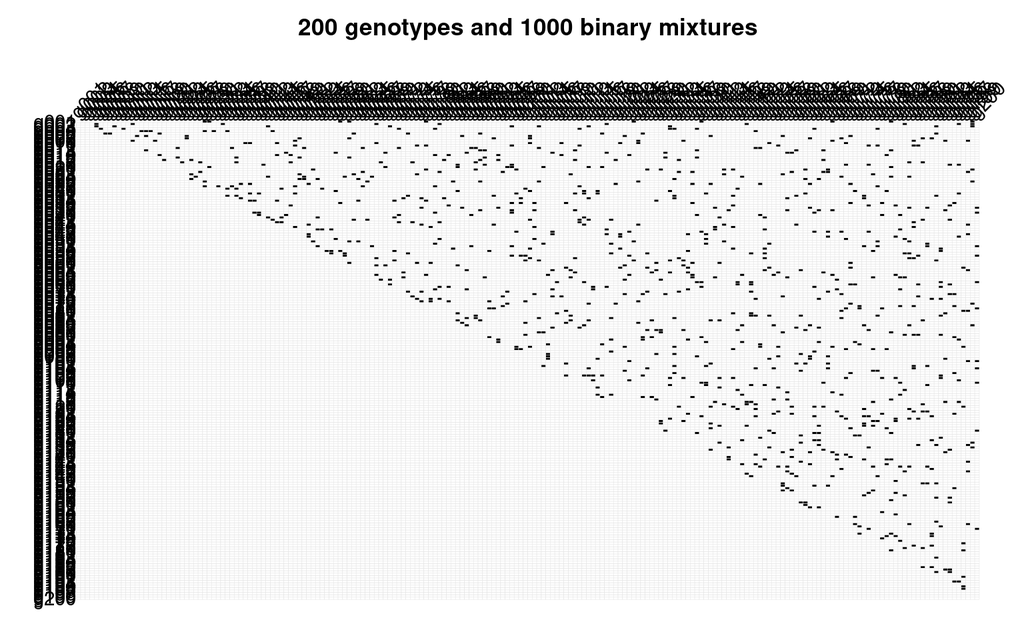

### 3.2.2 Field trial

```r
monoStands <- paste(levGenos, levGenos, sep = "_")

pairs <- design$combs
mixStands <- paste(pairs[, 1], pairs[, 2], sep = "_")
IDs <- c(monoStands, mixStands)

nbBlocks <- 3
blocks <- LETTERS[1:nbBlocks]

dat <- do.call(rbind, lapply(blocks, function(block) {
  data.frame(
    ID = IDs,
    block = block,
    stringsAsFactors = TRUE
  )
}))
```

### 3.2.3 Design matrices

```r
listContr <- list(block = "contr.sum")
X <- model.matrix(~ 1 + block, data = dat, contrasts = listContr)

allZ <- list()
allZ$GMA <- mkZGMA(dat, col = "ID", sep = "_")
system.time(
  allZ <- append(
    allZ,
    mkAllZSMA(dat, col = "ID", sep = "_", verbose = 1)
  )
)
```

```
## [1] "model 2'"
## [1] "model 2"
## [1] "model 2''"
## [1] "model 3"
## [1] "model 3'"
##    user  system elapsed
##  29.428   1.464  30.895
```

```r
sapply(allZ, dim)
```

```
##       GMA SMA_mod2p SMA_mod2 SMA_mod2pp_ij SMA_mod2pp_ii SMA_mod3 SMA_mod3p_ij
## [1,] 3600      3600     3600          3600          3600     3600         3600
## [2,]  200      1000     1200          1000           200     1200         1000
##      SMA_mod3p_ii
## [1,]         3600
## [2,]          200
```

### 3.2.4 Parameters

Several packages will be tested below, most notably `lme4` and `TMB`. However, `lme4` does not natively take a GRM as input. Hence the GRM will be replaced by the identity matrix to ensure a fair comparison between packages.

```r
truth <- list(
  "intercept" = 100,
  "var_GMA" = 10,
  "var_SMA" = 2,
  "var_SMA_ij" = 1.5,
  "var_SMA_ii" = 0.8,
  "var_error" = 1
)
set.seed(1234)
truth[["blockEffs"]] <- sample(x = c(-1, 1), size = nbBlocks - 1, replace = TRUE) *
  rnorm(n = nbBlocks - 1, mean = 3, sd = 2)
GRM <- diag(nbGenos)
truth[["GMAs"]] <- MASS::mvrnorm(
  n = 1, mu = rep(0, nbGenos),
  Sigma = truth$var_GMA * GRM
)
truth[["SMAs"]] <- rnorm(n = length(IDs), mean = 0, sd = sqrt(truth$var_SMA))
truth[["SMAs_ij"]] <- rnorm(n = length(mixStands), mean = 0, sd = sqrt(truth$var_SMA_ij))
truth[["SMAs_ii"]] <- rnorm(n = length(monoStands), mean = 0, sd = sqrt(truth$var_SMA_ii))
truth[["errors"]] <- rnorm(n = nrow(dat), mean = 0, sd = sqrt(truth$var_error))
```

### 3.2.5 Phenotypes

```r
y1 <- X %*% c(truth$intercept, truth$blockEffs) +
  allZ$GMA %*% truth$GMAs +
  truth$errors
dat$pheno1 <- y1[, 1]

y2 <- X %*% c(truth$intercept, truth$blockEffs) +
  allZ$GMA %*% truth$GMAs +
  allZ$SMA_mod2 %*% truth$SMAs +
  truth$errors
dat$pheno2 <- y2[, 1]

y3 <- X %*% c(truth$intercept, truth$blockEffs) +
  allZ$GMA %*% truth$GMAs +
  allZ$SMA_mod3 %*% truth$SMAs +
  truth$errors
dat$pheno3 <- y3[, 1]

y2p <- X %*% c(truth$intercept, truth$blockEffs) +
  allZ$GMA %*% truth$GMAs +
  allZ$SMA_mod2p %*% truth$SMAs_ij +
  truth$errors
dat$pheno2p <- y2p[, 1]

y2pp <- X %*% c(truth$intercept, truth$blockEffs) +
  allZ$GMA %*% truth$GMAs +
  allZ$SMA_mod2pp_ij %*% truth$SMAs_ij +
  allZ$SMA_mod2pp_ii %*% truth$SMAs_ii +
  truth$errors
dat$pheno2pp <- y2pp[, 1]

y3p <- X %*% c(truth$intercept, truth$blockEffs) +
  allZ$GMA %*% truth$GMAs +
  allZ$SMA_mod3p_ij %*% truth$SMAs_ij +
  allZ$SMA_mod3p_ii %*% truth$SMAs_ii +
  truth$errors
dat$pheno3p <- y3p[, 1]
```

# 4 Infer the parameters

Function `fitGMASMA` allows to fit the models with various packages. In this vignette, only `lme4` and `TMB` will be used and, as you can see below, both return the same estimates. (To save time, MM4LMM is commented.)

```r
pkgs <- c("lme4", "TMB") # , "MM4LMM")
if ("MM4LMM" %in% pkgs) {
  suppressPackageStartupMessages(library(MM4LMM))
}

runAllPkgs <- function(pkgs, form, dat, listZ, listVCov, listContr, ...) {
  ## mcMap(function(pkg) {
  Map(function(pkg) {
    print(paste0("fit with ", pkg, "..."))
    fitGMASMA(form, dat, listZ, pkg, listVCov, listContr)
    st <- system.time(
      try(fit <- fitGMASMA(form, dat, listZ, pkg, listVCov, listContr, REML = TRUE, ...))
    )
    print(st)
    fit
  }, pkgs) # , mc.cores = nbCores)
}
```

## 4.1 Model 1

### 4.1.1 Fit

```r
form <- pheno1 ~ 1 + block
listZ <- list("GMA" = allZ$GMA)
listVCov <- list("GMA" = GRM)
listContr <- list(block = "contr.sum")
fits1 <- runAllPkgs(pkgs, form, dat, listZ, listVCov, listContr)
```

```
## [1] "fit with lme4..."
##    user  system elapsed
##   0.501   0.000   0.501
## [1] "fit with TMB..."
##    user  system elapsed
##   3.824   0.000   3.824
```

### 4.1.2 Check

```r
print("lme4:")
```

```
## [1] "lme4:"
```

```r
tmp <- as.data.frame(VarCorr(fits1$lme4))
tmp <- setNames(tmp$vcov, tmp$grp)
checks <- data.frame(
  truth = do.call(c, truth[c("var_GMA", "var_error")]),
  estim = tmp[c("GMA", "Residual")]
)
checks$nBE <- normBiasError(checks$estim, checks$truth)
print(checks)
```

```
##           truth     estim       nBE
## var_GMA      10 10.294633  2.946325
## var_error     1  0.957673 -4.232704
```

```r
print("TMB:")
```

```
## [1] "TMB:"
```

```r
checks <- data.frame(
  truth = do.call(c, truth[c("var_GMA", "var_error")]),
  estim = do.call(c, fits1$TMB$report[c("var_GMA", "var_err")])
)
checks$nBE <- normBiasError(checks$estim, checks$truth)
print(checks)
```

```
##           truth     estim       nBE
## var_GMA      10 10.294632  2.946325
## var_error     1  0.957673 -4.232704
```

```r
if ("MM4LMM" %in% names(fits1)) {
  print(fits1$MM4LMM$Sigma2)
}
```

## 4.2 Model 2

### 4.2.1 Fit

```r
form <- pheno2 ~ 1 + block
listZ <- list(
  "GMA" = allZ$GMA,
  "SMA" = allZ$SMA_mod2
)
listVCov <- list(
  "GMA" = GRM,
  "SMA" = diag(ncol(listZ$SMA))
)
listContr <- list(block = "contr.sum")
fits2 <- runAllPkgs(pkgs, form, dat, listZ, listVCov, listContr)
```

```
## [1] "fit with lme4..."
##    user  system elapsed
##   1.497   0.001   1.497
## [1] "fit with TMB..."
##    user  system elapsed
##  11.226   0.036  11.263
```

### 4.2.2 Check

```r
print("lme4:")
```

```
## [1] "lme4:"
```

```r
tmp <- as.data.frame(VarCorr(fits2$lme4))
tmp <- setNames(tmp$vcov, tmp$grp)
checks <- data.frame(
  truth = do.call(c, truth[c("var_GMA", "var_SMA", "var_error")]),
  estim = tmp[c("GMA", "SMA", "Residual")]
)
checks$nBE <- normBiasError(checks$estim, checks$truth)
print(checks)
```

```
##           truth      estim        nBE
## var_GMA      10 10.1324793  1.3247926
## var_SMA       2  2.0113789  0.5689449
## var_error     1  0.9453839 -5.4616064
```

```r
print("TMB:")
```

```
## [1] "TMB:"
```

```r
checks <- data.frame(
  truth = do.call(c, truth[c("var_GMA", "var_SMA", "var_error")]),
  estim = do.call(c, fits2$TMB$report[c("var_GMA", "var_SMA1", "var_err")])
)
checks$nBE <- normBiasError(checks$estim, checks$truth)
print(checks)
```

```
##           truth      estim        nBE
## var_GMA      10 10.1324647  1.3246471
## var_SMA       2  2.0114019  0.5700966
## var_error     1  0.9453792 -5.4620796
```

```r
if ("MM4LMM" %in% names(fits2)) {
  print(fits2$MM4LMM$Sigma2)
}
```

## 4.3 Model 3

### 4.3.1 Fit

```r
form <- pheno3 ~ 1 + block
listZ <- list(
  "GMA" = allZ$GMA,
  "SMA" = allZ$SMA_mod3
)
listVCov <- list(
  "GMA" = GRM,
  "SMA" = diag(ncol(listZ$SMA))
)
listContr <- list(block = "contr.sum")
fits3 <- runAllPkgs(pkgs, form, dat, listZ, listVCov, listContr)
```

```
## [1] "fit with lme4..."
##    user  system elapsed
##   2.237   0.000   2.238
## [1] "fit with TMB..."
##    user  system elapsed
##  11.189   0.064  11.253
```

### 4.3.2 Check

```r
print("lme4:")
```

```
## [1] "lme4:"
```

```r
tmp <- as.data.frame(VarCorr(fits3$lme4))
tmp <- setNames(tmp$vcov, tmp$grp)
checks <- data.frame(
  truth = do.call(c, truth[c("var_GMA", "var_SMA", "var_error")]),
  estim = tmp[c("GMA", "SMA", "Residual")]
)
checks$nBE <- normBiasError(checks$estim, checks$truth)
print(checks)
```

```
##           truth     estim        nBE
## var_GMA      10 9.9758558 -0.2414422
## var_SMA       2 2.0811855  4.0592759
## var_error     1 0.9443071 -5.5692907
```

```r
print("TMB:")
```

```
## [1] "TMB:"
```

```r
checks <- data.frame(
  truth = do.call(c, truth[c("var_GMA", "var_SMA", "var_error")]),
  estim = do.call(c, fits3$TMB$report[c("var_GMA", "var_SMA1", "var_err")])
)
checks$nBE <- normBiasError(checks$estim, checks$truth)
print(checks)
```

```
##           truth     estim        nBE
## var_GMA      10 9.9758564 -0.2414362
## var_SMA       2 2.0811856  4.0592811
## var_error     1 0.9443071 -5.5692918
```

```r
if ("MM4LMM" %in% names(fits3)) {
  print(fits3$MM4LMM$Sigma2)
}
```

## 4.4 Model 2’

### 4.4.1 Fit

```r
form <- pheno2p ~ 1 + block
listZ <- list(
  "GMA" = allZ$GMA,
  "SMA" = allZ$SMA_mod2p
)
listVCov <- list(
  "GMA" = GRM,
  "SMA" = diag(ncol(listZ$SMA))
)
listContr <- list(block = "contr.sum")
fits2p <- runAllPkgs(pkgs, form, dat, listZ, listVCov, listContr)
```

```
## [1] "fit with lme4..."
## Warning in split.default(x, g): data length is not a multiple of split variable
## Warning in split.default(seq_along(x), f, drop = drop, ...): data length is not
## a multiple of split variable
## Warning in split.default(x, g): data length is not a multiple of split variable
## Warning in split.default(seq_along(x), f, drop = drop, ...): data length is not
## a multiple of split variable
##    user  system elapsed
##   1.448   0.000   1.447
## [1] "fit with TMB..."
##    user  system elapsed
##   9.622   0.068   9.691
```

### 4.4.2 Check

```r
print("lme4:")
```

```
## [1] "lme4:"
```

```r
tmp <- as.data.frame(VarCorr(fits2p$lme4))
tmp <- setNames(tmp$vcov, tmp$grp)
checks <- data.frame(
  truth = do.call(c, truth[c("var_GMA", "var_SMA", "var_error")]),
  estim = tmp[c("GMA", "SMA", "Residual")]
)
checks$nBE <- normBiasError(checks$estim, checks$truth)
print(checks)
```

```
##           truth     estim        nBE
## var_GMA      10 10.428119   4.281193
## var_SMA       2  1.544762 -22.761905
## var_error     1  0.946256  -5.374396
```

```r
print("TMB:")
```

```
## [1] "TMB:"
```

```r
checks <- data.frame(
  truth = do.call(c, truth[c("var_GMA", "var_SMA", "var_error")]),
  estim = do.call(c, fits2p$TMB$report[c("var_GMA", "var_SMA1", "var_err")])
)
checks$nBE <- normBiasError(checks$estim, checks$truth)
print(checks)
```

```
##           truth     estim        nBE
## var_GMA      10 10.428119   4.281189
## var_SMA       2  1.544761 -22.761929
## var_error     1  0.946256  -5.374396
```

```r
if ("MM4LMM" %in% names(fits2p)) {
  print(fits2p$MM4LMM$Sigma2)
}
```

## 4.5 Model 2’’

### 4.5.1 Fit

```r
form <- pheno2pp ~ 1 + block
listZ <- list(
  "GMA" = allZ$GMA,
  "SMA_ij" = allZ$SMA_mod2pp_ij,
  "SMA_ii" = allZ$SMA_mod2pp_ii
)
listVCov <- list(
  "GMA" = GRM,
  "SMA_ij" = diag(ncol(listZ$SMA_ij)),
  "SMA_ii" = diag(ncol(listZ$SMA_ii))
)
listContr <- list(block = "contr.sum")
fits2pp <- runAllPkgs(pkgs, form, dat, listZ, listVCov, listContr)
```

```
## [1] "fit with lme4..."
## Warning in split.default(x, g): data length is not a multiple of split variable
## Warning in split.default(seq_along(x), f, drop = drop, ...): data length is not
## a multiple of split variable
## Warning in split.default(x, g): data length is not a multiple of split variable
## Warning in split.default(seq_along(x), f, drop = drop, ...): data length is not
## a multiple of split variable
##    user  system elapsed
##   4.454   0.000   4.460
## [1] "fit with TMB..."
##    user  system elapsed
##  11.405   0.052  11.460
```

### 4.5.2 Check

```r
print("lme4:")
```

```
## [1] "lme4:"
```

```r
tmp <- as.data.frame(VarCorr(fits2pp$lme4))
tmp <- setNames(tmp$vcov, tmp$grp)
checks <- data.frame(
  truth = do.call(c, truth[c("var_GMA", "var_SMA_ij", "var_SMA_ii", "var_error")]),
  estim = tmp[c("GMA", "SMA_ij", "SMA_ii", "Residual")]
)
checks$nBE <- normBiasError(checks$estim, checks$truth)
print(checks)
```

```
##            truth      estim       nBE
## var_GMA     10.0 10.1734023  1.734023
## var_SMA_ij   1.5  1.5577029  3.846860
## var_SMA_ii   0.8  0.8390411  4.880133
## var_error    1.0  0.9453835 -5.461654
```

```r
print("TMB:")
```

```
## [1] "TMB:"
```

```r
checks <- data.frame(
  truth = do.call(c, truth[c("var_GMA", "var_SMA_ij", "var_SMA_ii", "var_error")]),
  estim = do.call(c, fits2pp$TMB$report[c("var_GMA", "var_SMA1", "var_SMA2", "var_err")])
)
checks$nBE <- normBiasError(checks$estim, checks$truth)
print(checks)
```

```
##            truth      estim       nBE
## var_GMA     10.0 10.1733882  1.733882
## var_SMA_ij   1.5  1.5577032  3.846877
## var_SMA_ii   0.8  0.8390382  4.879774
## var_error    1.0  0.9453838 -5.461621
```

```r
if ("MM4LMM" %in% names(fits2pp)) {
  print(fits2pp$MM4LMM$Sigma2)
}
```

## 4.6 Model 3’

### 4.6.1 Fit

```r
form <- pheno3p ~ 1 + block
listZ <- list(
  "GMA" = allZ$GMA,
  "SMA_ij" = allZ$SMA_mod3p_ij,
  "SMA_ii" = allZ$SMA_mod3p_ii
)
listVCov <- list(
  "GMA" = GRM,
  "SMA_ij" = diag(ncol(listZ$SMA_ij)),
  "SMA_ii" = diag(ncol(listZ$SMA_ii))
)
listContr <- list(block = "contr.sum")
fits3p <- runAllPkgs(pkgs, form, dat, listZ, listVCov, listContr)
```

```
## [1] "fit with lme4..."
## Warning in split.default(x, g): data length is not a multiple of split variable
## Warning in split.default(seq_along(x), f, drop = drop, ...): data length is not
## a multiple of split variable
## Warning in split.default(x, g): data length is not a multiple of split variable
## Warning in split.default(seq_along(x), f, drop = drop, ...): data length is not
## a multiple of split variable
##    user  system elapsed
##   3.792   0.000   3.792
## [1] "fit with TMB..."
##    user  system elapsed
##  13.325   0.164  13.490
```

### 4.6.2 Check

```r
print("lme4:")
```

```
## [1] "lme4:"
```

```r
tmp <- as.data.frame(VarCorr(fits3p$lme4))
tmp <- setNames(tmp$vcov, tmp$grp)
checks <- data.frame(
  truth = do.call(c, truth[c("var_GMA", "var_SMA_ij", "var_SMA_ii", "var_error")]),
  estim = tmp[c("GMA", "SMA_ij", "SMA_ii", "Residual")]
)
checks$nBE <- normBiasError(checks$estim, checks$truth)
print(checks)
```

```
##            truth     estim        nBE
## var_GMA     10.0 9.9892439 -0.1075612
## var_SMA_ij   1.5 1.5390438  2.6029207
## var_SMA_ii   0.8 0.9997089 24.9636064
## var_error    1.0 0.9440616 -5.5938365
```

```r
print("TMB:")
```

```
## [1] "TMB:"
```

```r
checks <- data.frame(
  truth = do.call(c, truth[c("var_GMA", "var_SMA_ij", "var_SMA_ii", "var_error")]),
  estim = do.call(c, fits3p$TMB$report[c("var_GMA", "var_SMA1", "var_SMA2", "var_err")])
)
checks$nBE <- normBiasError(checks$estim, checks$truth)
print(checks)
```

```
##            truth     estim        nBE
## var_GMA     10.0 9.9892539 -0.1074613
## var_SMA_ij   1.5 1.5390442  2.6029496
## var_SMA_ii   0.8 0.9997069 24.9633674
## var_error    1.0 0.9440616 -5.5938432
```

```r
if ("MM4LMM" %in% names(fits3p)) {
  print(fits3p$MM4LMM$Sigma2)
}
```

# 5 Appendix

```r
t1 <- proc.time()
t1 - t0
```

```
##    user  system elapsed
## 191.285   2.615 193.915
```